# Project: Tmdb Movies

- Introduction
- Data Wrangling
- Exploratory Data Analysis
- Conclusions

## Introduction

> **Hi, Dear Reader**

welcome to this project, below i will starting to analyze TMdp Movies dataset,this data set contains information about 10,000 movies collected from The Movie Database (TMDb), including user ratings and revenue, we will use the learned consepts to investgate the dataset, let's start!

```python
# import the needed packages for analysis.
import pandas as pd
import numpy as np
import matplotlib.pyplot as plt
import seaborn as sns
%matplotlib inline
```

```python
# load the csv file
df = pd.read_csv ( 'tmdb-movies.csv')
df.head()
```

|  | id | imdb_id | popularity | budget | revenue | original_title | cast | homepage | director | tagline | ... | overview | runtime | genres | production_companies | release_date | vote_count | vote_average | release_year | budget_adj | revenue_adj |
| --- | --- | --- | --- | --- | --- | --- | --- | --- | --- | --- | --- | --- | --- | --- | --- | --- | --- | --- | --- | --- | --- |
| 0 | 135397 | tt0369610 | 32.985763 | 150000000 | 1513528810 | Jurassic World | Chris Pratt\|Bryce Dallas Howard\|Irrfan Khan\|Vi... | http://www.jurassicworld.com/ | Colin Trevorrow | The park is open. | ... | Twenty-two years after the events of Jurassic ... | 124 | Action\|Adventure\|Science Fiction\|Thriller | Universal Studios\|Amblin Entertainment\|Legenda... | 6/9/15 | 5562 | 6.5 | 2015 | 1.379999e+08 | 1.392446e+09 |
| 1 | 76341 | tt1392190 | 28.419936 | 150000000 | 378436354 | Mad Max: Fury Road | Tom Hardy\|Charlize Theron\|Hugh Keays-Byrne\|Nic... | http://www.madmaxmovie.com/ | George Miller | What a Lovely Day. | ... | An apocalyptic story set in the furthest reach... | 120 | Action\|Adventure\|Science Fiction\|Thriller | Village Roadshow Pictures\|Kennedy Miller Produ... | 5/13/15 | 6185 | 7.1 | 2015 | 1.379999e+08 | 3.481613e+08 |
| 2 | 262500 | tt2908446 | 13.112507 | 110000000 | 295238201 | Insurgent | Shailene Woodley\|Theo James\|Kate Winslet\|Ansel... | http://www.thedivergentseries.movie/#insurgent | Robert Schwentke | One Choice Can Destroy You | ... | Beatrice Prior must confront her inner demons ... | 119 | Adventure\|Science Fiction\|Thriller | Summit Entertainment\|Mandeville Films\|Red Wago... | 3/18/15 | 2480 | 6.3 | 2015 | 1.012000e+08 | 2.716190e+08 |
| 3 | 140607 | tt2488496 | 11.173104 | 200000000 | 2068178225 | Star Wars: The Force Awakens | Harrison Ford\|Mark Hamill\|Carrie Fisher\|Adam D... | http://www.starwars.com/films/star-wars-episod... | J.J. Abrams | Every generation has a story. | ... | Thirty years after defeating the Galactic Empi... | 136 | Action\|Adventure\|Science Fiction\|Fantasy | Lucasfilm\|Truenorth Productions\|Bad Robot | 12/15/15 | 5292 | 7.5 | 2015 | 1.839999e+08 | 1.902723e+09 |
| 4 | 168259 | tt2820852 | 9.335014 | 190000000 | 1506249360 | Furious 7 | Vin Diesel\|Paul Walker\|Jason Statham\|Michelle ... | http://www.furious7.com/ | James Wan | Vengeance Hits Home | ... | Deckard Shaw seeks revenge against Dominic Tor... | 137 | Action\|Crime\|Thriller | Universal Pictures\|Original Film\|Media Rights ... | 4/1/15 | 2947 | 7.3 | 2015 | 1.747999e+08 | 1.385749e+09 |

5 rows × 21 columns

Here, in this project we will try to answer the following questions:

**Q1: What is the average profits of movies by years?**

**Q2: What is the top 10 prfits movies?**

**Q3: How vote average affected by increasing or decreasing?**

**Q4: Which mounth is better to relase the movie?**

## Data Wrangling

```python
df.head()
```

|  | id | imdb_id | popularity | budget | revenue | original_title | cast | homepage | director | tagline | ... | overview | runtime | genres | production_companies | release_date | vote_count | vote_average | release_year | budget_adj | revenue_adj |
| --- | --- | --- | --- | --- | --- | --- | --- | --- | --- | --- | --- | --- | --- | --- | --- | --- | --- | --- | --- | --- | --- |
| 0 | 135397 | tt0369610 | 32.985763 | 150000000 | 1513528810 | Jurassic World | Chris Pratt\|Bryce Dallas Howard\|Irrfan Khan\|Vi... | http://www.jurassicworld.com/ | Colin Trevorrow | The park is open. | ... | Twenty-two years after the events of Jurassic ... | 124 | Action\|Adventure\|Science Fiction\|Thriller | Universal Studios\|Amblin Entertainment\|Legenda... | 6/9/15 | 5562 | 6.5 | 2015 | 1.379999e+08 | 1.392446e+09 |
| 1 | 76341 | tt1392190 | 28.419936 | 150000000 | 378436354 | Mad Max: Fury Road | Tom Hardy\|Charlize Theron\|Hugh Keays-Byrne\|Nic... | http://www.madmaxmovie.com/ | George Miller | What a Lovely Day. | ... | An apocalyptic story set in the furthest reach... | 120 | Action\|Adventure\|Science Fiction\|Thriller | Village Roadshow Pictures\|Kennedy Miller Produ... | 5/13/15 | 6185 | 7.1 | 2015 | 1.379999e+08 | 3.481613e+08 |
| 2 | 262500 | tt2908446 | 13.112507 | 110000000 | 295238201 | Insurgent | Shailene Woodley\|Theo James\|Kate Winslet\|Ansel... | http://www.thedivergentseries.movie/#insurgent | Robert Schwentke | One Choice Can Destroy You | ... | Beatrice Prior must confront her inner demons ... | 119 | Adventure\|Science Fiction\|Thriller | Summit Entertainment\|Mandeville Films\|Red Wago... | 3/18/15 | 2480 | 6.3 | 2015 | 1.012000e+08 | 2.716190e+08 |
| 3 | 140607 | tt2488496 | 11.173104 | 200000000 | 2068178225 | Star Wars: The Force Awakens | Harrison Ford\|Mark Hamill\|Carrie Fisher\|Adam D... | http://www.starwars.com/films/star-wars-episod... | J.J. Abrams | Every generation has a story. | ... | Thirty years after defeating the Galactic Empi... | 136 | Action\|Adventure\|Science Fiction\|Fantasy | Lucasfilm\|Truenorth Productions\|Bad Robot | 12/15/15 | 5292 | 7.5 | 2015 | 1.839999e+08 | 1.902723e+09 |
| 4 | 168259 | tt2820852 | 9.335014 | 190000000 | 1506249360 | Furious 7 | Vin Diesel\|Paul Walker\|Jason Statham\|Michelle ... | http://www.furious7.com/ | James Wan | Vengeance Hits Home | ... | Deckard Shaw seeks revenge against Dominic Tor... | 137 | Action\|Crime\|Thriller | Universal Pictures\|Original Film\|Media Rights ... | 4/1/15 | 2947 | 7.3 | 2015 | 1.747999e+08 | 1.385749e+09 |

5 rows × 21 columns

```python
df.shape
```

```
(10866, 21)
```

```python
df.info()
```

```
<class 'pandas.core.frame.DataFrame'>
RangeIndex: 10866 entries, 0 to 10865
Data columns (total 21 columns):
 #   Column                Non-Null Count  Dtype
---  ------                --------------  -----
 0   id                    10866 non-null  int64
 1   imdb_id               10856 non-null  object
 2   popularity            10866 non-null  float64
 3   budget                10866 non-null  int64
 4   revenue               10866 non-null  int64
 5   original_title        10866 non-null  object
 6   cast                  10790 non-null  object
 7   homepage              2936 non-null   object
 8   director              10822 non-null  object
 9   tagline               8042 non-null   object
 10  keywords              9373 non-null   object
 11  overview              10862 non-null  object
 12  runtime               10866 non-null  int64
 13  genres                10843 non-null  object
 14  production_companies  9836 non-null   object
 15  release_date          10866 non-null  object
 16  vote_count            10866 non-null  int64
 17  vote_average          10866 non-null  float64
 18  release_year          10866 non-null  int64
 19  budget_adj            10866 non-null  float64
 20  revenue_adj           10866 non-null  float64
dtypes: float64(4), int64(6), object(11)
memory usage: 1.7+ MB
```

```python
df.describe()
```

|  | id | popularity | budget | revenue | runtime | vote_count | vote_average | release_year | budget_adj | revenue_adj |
| --- | --- | --- | --- | --- | --- | --- | --- | --- | --- | --- |
| count | 10866.000000 | 10866.000000 | 1.086600e+04 | 1.086600e+04 | 10866.000000 | 10866.000000 | 10866.000000 | 10866.000000 | 1.086600e+04 | 1.086600e+04 |
| mean | 66064.177434 | 0.646441 | 1.462570e+07 | 3.982332e+07 | 102.070863 | 217.389748 | 5.974922 | 2001.322658 | 1.755104e+07 | 5.136436e+07 |
| std | 92130.136561 | 1.000185 | 3.091321e+07 | 1.170035e+08 | 31.381405 | 575.619058 | 0.935142 | 12.812941 | 3.430616e+07 | 1.446325e+08 |
| min | 5.000000 | 0.000065 | 0.000000e+00 | 0.000000e+00 | 0.000000 | 10.000000 | 1.500000 | 1960.000000 | 0.000000e+00 | 0.000000e+00 |
| 25% | 10596.250000 | 0.207583 | 0.000000e+00 | 0.000000e+00 | 90.000000 | 17.000000 | 5.400000 | 1995.000000 | 0.000000e+00 | 0.000000e+00 |
| 50% | 20669.000000 | 0.383856 | 0.000000e+00 | 0.000000e+00 | 99.000000 | 38.000000 | 6.000000 | 2006.000000 | 0.000000e+00 | 0.000000e+00 |
| 75% | 75610.000000 | 0.713817 | 1.500000e+07 | 2.400000e+07 | 111.000000 | 145.750000 | 6.600000 | 2011.000000 | 2.085325e+07 | 3.369710e+07 |
| max | 417859.000000 | 32.985763 | 4.250000e+08 | 2.781506e+09 | 900.000000 | 9767.000000 | 9.200000 | 2015.000000 | 4.250000e+08 | 2.827124e+09 |

```python
df.dtypes
```

```
id                        int64
imdb_id                  object
popularity              float64
budget                    int64
revenue                   int64
original_title           object
cast                     object
homepage                 object
director                 object
tagline                  object
keywords                 object
overview                 object
runtime                   int64
genres                   object
production_companies     object
release_date             object
vote_count                int64
vote_average            float64
release_year              int64
budget_adj              float64
revenue_adj             float64
dtype: object
```

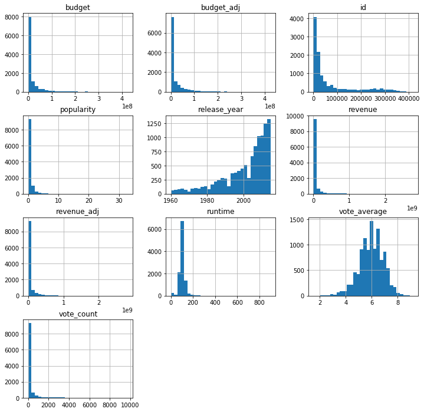

```python
df.hist(figsize= (12,12), bins=30);
```

**General Notes**

- from the above, we have in our dataset 10866 rows and 21 columns.
- we have a lot of null-values rows and we need to deal with it if it necessery.
- different of datatypes, need to be more orgnized,
- from the histograme, we can see the revenue,budget have zeros valus, so we hvae to see what we can do with it!
- all columns name come with lower cases, why we don't try to make it more nice with upper cases?

**TO Do:**

1. remove unless columns from the dataset.
2. check about null-values,duplicate and deleted it to increae data quality.
3. cahnge data types.
4. cahnge columns name to upper cases.

```python
df.head()
```

|  | id | imdb_id | popularity | budget | revenue | original_title | cast | homepage | director | tagline | ... | overview | runtime | genres | production_companies | release_date | vote_count | vote_average | release_year | budget_adj | revenue_adj |
| --- | --- | --- | --- | --- | --- | --- | --- | --- | --- | --- | --- | --- | --- | --- | --- | --- | --- | --- | --- | --- | --- |
| 0 | 135397 | tt0369610 | 32.985763 | 150000000 | 1513528810 | Jurassic World | Chris Pratt\|Bryce Dallas Howard\|Irrfan Khan\|Vi... | http://www.jurassicworld.com/ | Colin Trevorrow | The park is open. | ... | Twenty-two years after the events of Jurassic ... | 124 | Action\|Adventure\|Science Fiction\|Thriller | Universal Studios\|Amblin Entertainment\|Legenda... | 6/9/15 | 5562 | 6.5 | 2015 | 1.379999e+08 | 1.392446e+09 |
| 1 | 76341 | tt1392190 | 28.419936 | 150000000 | 378436354 | Mad Max: Fury Road | Tom Hardy\|Charlize Theron\|Hugh Keays-Byrne\|Nic... | http://www.madmaxmovie.com/ | George Miller | What a Lovely Day. | ... | An apocalyptic story set in the furthest reach... | 120 | Action\|Adventure\|Science Fiction\|Thriller | Village Roadshow Pictures\|Kennedy Miller Produ... | 5/13/15 | 6185 | 7.1 | 2015 | 1.379999e+08 | 3.481613e+08 |
| 2 | 262500 | tt2908446 | 13.112507 | 110000000 | 295238201 | Insurgent | Shailene Woodley\|Theo James\|Kate Winslet\|Ansel... | http://www.thedivergentseries.movie/#insurgent | Robert Schwentke | One Choice Can Destroy You | ... | Beatrice Prior must confront her inner demons ... | 119 | Adventure\|Science Fiction\|Thriller | Summit Entertainment\|Mandeville Films\|Red Wago... | 3/18/15 | 2480 | 6.3 | 2015 | 1.012000e+08 | 2.716190e+08 |
| 3 | 140607 | tt2488496 | 11.173104 | 200000000 | 2068178225 | Star Wars: The Force Awakens | Harrison Ford\|Mark Hamill\|Carrie Fisher\|Adam D... | http://www.starwars.com/films/star-wars-episod... | J.J. Abrams | Every generation has a story. | ... | Thirty years after defeating the Galactic Empi... | 136 | Action\|Adventure\|Science Fiction\|Fantasy | Lucasfilm\|Truenorth Productions\|Bad Robot | 12/15/15 | 5292 | 7.5 | 2015 | 1.839999e+08 | 1.902723e+09 |
| 4 | 168259 | tt2820852 | 9.335014 | 190000000 | 1506249360 | Furious 7 | Vin Diesel\|Paul Walker\|Jason Statham\|Michelle ... | http://www.furious7.com/ | James Wan | Vengeance Hits Home | ... | Deckard Shaw seeks revenge against Dominic Tor... | 137 | Action\|Crime\|Thriller | Universal Pictures\|Original Film\|Media Rights ... | 4/1/15 | 2947 | 7.3 | 2015 | 1.747999e+08 | 1.385749e+09 |

5 rows × 21 columns

```python
# here i will drop unless columns from the dataset
df.drop(['imdb_id','cast','director','homepage','tagline','overview','genres',
'production_companies','vote_count','budget_adj','revenue_adj','keywords'],
        axis=1,inplace=True)
```

```python
# check for the head of dataset after drop the unless columns
df.head(3)
```

|  | id | popularity | budget | revenue | original_title | runtime | release_date | vote_average | release_year |
| --- | --- | --- | --- | --- | --- | --- | --- | --- | --- |
| 0 | 135397 | 32.985763 | 150000000 | 1513528810 | Jurassic World | 124 | 6/9/15 | 6.5 | 2015 |
| 1 | 76341 | 28.419936 | 150000000 | 378436354 | Mad Max: Fury Road | 120 | 5/13/15 | 7.1 | 2015 |
| 2 | 262500 | 13.112507 | 110000000 | 295238201 | Insurgent | 119 | 3/18/15 | 6.3 | 2015 |

```python
# check for null values
df.isnull().sum()
```

```
id                0
popularity        0
budget            0
revenue           0
original_title    0
runtime           0
release_date      0
vote_average      0
release_year      0
dtype: int64
```

```python
# as we know, there is a lot of zeros values whith budget and revenue that we need to delete it do improve quality of data,
# we will check how many rows are zeors.
print(df[df['budget']==0].shape)
print (df[df['revenue']==0].shape)
```

```
(5696, 9)
(6016, 9)
```

```python
# as the above, the easy way to drop the zero's values is to make it as null values, then drop it.
df['budget'] = df['budget'].replace(0, np.NaN)
df['revenue'] = df['revenue'].replace(0, np.NaN)
df.dropna(inplace =True)
```

```python
# now we will check if our work is correct
print(df[df['budget']==0].shape)
print (df[df['revenue']==0].shape)
```

```
(0, 9)
(0, 9)
```

```python
# nice, now we will chevc for duplicates to remove it
df.duplicated().sum()
```

```
1
```

```python
# drop the duplicates
df.drop_duplicates(inplace=True)
```

```python
# check if everything is okey
print(df.isnull().sum())
print(df.duplicated().sum())
```

```
id                0
popularity        0
budget            0
revenue           0
original_title    0
runtime           0
release_date      0
vote_average      0
release_year      0
dtype: int64
0
```

```python
# Now,i will check for datatypes
df.dtypes
```

```
id                  int64
popularity        float64
budget            float64
revenue           float64
original_title     object
runtime             int64
release_date       object
vote_average      float64
release_year        int64
dtype: object
```

```python
# i will change the release date column to date types,
df['release_date'] = pd.to_datetime(df['release_date'])
df['popularity'] = df['popularity'].astype(int)
df['budget'] = df['budget'].astype(int)
df['revenue'] = df['revenue'].astype(int)
```

```python
df.dtypes
```

```
id                         int64
popularity                 int32
budget                     int32
revenue                    int32
original_title            object
runtime                    int64
release_date      datetime64[ns]
vote_average             float64
release_year               int64
dtype: object
```

```python
# now, to orginze the columns name, i will change it with Uppercase
df.columns = map(str.upper, df.columns)
df.head()
```

|  | ID | POPULARITY | BUDGET | REVENUE | ORIGINAL_TITLE | RUNTIME | RELEASE_DATE | VOTE_AVERAGE | RELEASE_YEAR |
| --- | --- | --- | --- | --- | --- | --- | --- | --- | --- |
| 0 | 135397 | 32 | 150000000 | 1513528810 | Jurassic World | 124 | 2015-06-09 | 6.5 | 2015 |
| 1 | 76341 | 28 | 150000000 | 378436354 | Mad Max: Fury Road | 120 | 2015-05-13 | 7.1 | 2015 |
| 2 | 262500 | 13 | 110000000 | 295238201 | Insurgent | 119 | 2015-03-18 | 6.3 | 2015 |
| 3 | 140607 | 11 | 200000000 | 2068178225 | Star Wars: The Force Awakens | 136 | 2015-12-15 | 7.5 | 2015 |
| 4 | 168259 | 9 | 190000000 | 1506249360 | Furious 7 | 137 | 2015-04-01 | 7.3 | 2015 |

```python
df.info()
```

```
<class 'pandas.core.frame.DataFrame'>
Int64Index: 3854 entries, 0 to 10848
Data columns (total 9 columns):
 #   Column          Non-Null Count  Dtype
---  ------          --------------  -----
 0   ID              3854 non-null   int64
 1   POPULARITY      3854 non-null   int32
 2   BUDGET          3854 non-null   int32
 3   REVENUE         3854 non-null   int32
 4   ORIGINAL_TITLE  3854 non-null   object
 5   RUNTIME         3854 non-null   int64
 6   RELEASE_DATE    3854 non-null   datetime64[ns]
 7   VOTE_AVERAGE    3854 non-null   float64
 8   RELEASE_YEAR    3854 non-null   int64
dtypes: datetime64[ns](1), float64(1), int32(3), int64(3), object(1)
memory usage: 255.9+ KB
```

## Exploratory Data Analysis

> **Now**: ourdataset is cleaning,nice without missing-values,zeros-values,duplicated-values and unless columns, so we are ready now to starting the next important step ( Exploratory Data Analysis )

> **Let's Go!**

### Research Question1: What is the average profits of movies over years?

```python
df.head(10)
```

|  | ID | POPULARITY | BUDGET | REVENUE | ORIGINAL_TITLE | RUNTIME | RELEASE_DATE | VOTE_AVERAGE | RELEASE_YEAR |
| --- | --- | --- | --- | --- | --- | --- | --- | --- | --- |
| 0 | 135397 | 32 | 150000000 | 1513528810 | Jurassic World | 124 | 2015-06-09 | 6.5 | 2015 |
| 1 | 76341 | 28 | 150000000 | 378436354 | Mad Max: Fury Road | 120 | 2015-05-13 | 7.1 | 2015 |
| 2 | 262500 | 13 | 110000000 | 295238201 | Insurgent | 119 | 2015-03-18 | 6.3 | 2015 |
| 3 | 140607 | 11 | 200000000 | 2068178225 | Star Wars: The Force Awakens | 136 | 2015-12-15 | 7.5 | 2015 |
| 4 | 168259 | 9 | 190000000 | 1506249360 | Furious 7 | 137 | 2015-04-01 | 7.3 | 2015 |
| 5 | 281957 | 9 | 135000000 | 532950503 | The Revenant | 156 | 2015-12-25 | 7.2 | 2015 |
| 6 | 87101 | 8 | 155000000 | 440603537 | Terminator Genisys | 125 | 2015-06-23 | 5.8 | 2015 |
| 7 | 286217 | 7 | 108000000 | 595380321 | The Martian | 141 | 2015-09-30 | 7.6 | 2015 |
| 8 | 211672 | 7 | 74000000 | 1156730962 | Minions | 91 | 2015-06-17 | 6.5 | 2015 |
| 9 | 150540 | 6 | 175000000 | 853708609 | Inside Out | 94 | 2015-06-09 | 8.0 | 2015 |

```python
# Here we will calculate the profits first as new column in our dataset
df['PROFITS'] = df['REVENUE'] - df['BUDGET']
df['REVENUE'] = df['REVENUE'].astype(int)
df.head(1)
```

|  | ID | POPULARITY | BUDGET | REVENUE | ORIGINAL_TITLE | RUNTIME | RELEASE_DATE | VOTE_AVERAGE | RELEASE_YEAR | PROFITS |
| --- | --- | --- | --- | --- | --- | --- | --- | --- | --- | --- |
| 0 | 135397 | 32 | 150000000 | 1513528810 | Jurassic World | 124 | 2015-06-09 | 6.5 | 2015 | 1363528810 |

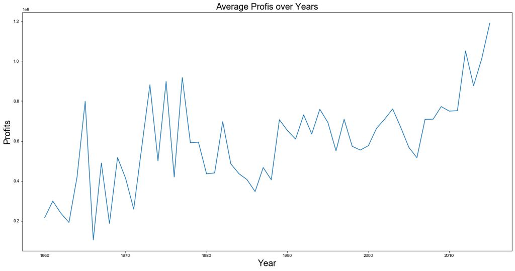

```python
# Now, we will plot the line chart to see the average profits over years

df.groupby('RELEASE_YEAR')['PROFITS'].mean().plot(figsize=(20, 10))
plt.title("Average Profis over Years",fontsize = 20)
plt.xlabel('Year',fontsize = 20)
plt.ylabel('Profits',fontsize = 20)
sns.set_style("whitegrid")
```

as we can see here, the profits of movies over years are increaseing from 2010 and it was regisred low profits between 1985 until 1990

## ### Research Question2: What is the top 10 prfits,budget movies?

```python
# using the below function, we will extrat the top 10 profti movies.
Top_Profits = pd.DataFrame(df.nlargest(10,'PROFITS'))
# now let's check the result
Top_Profits
```

|  | ID | POPULARITY | BUDGET | REVENUE | ORIGINAL_TITLE | RUNTIME | RELEASE_DATE | VOTE_AVERAGE | RELEASE_YEAR | PROFITS |
| --- | --- | --- | --- | --- | --- | --- | --- | --- | --- | --- |
| 1386 | 19995 | 9 | 237000000 | -2147483648 | Avatar | 162 | 2009-12-10 | 7.1 | 2009 | 1910483648 |
| 3 | 140607 | 11 | 200000000 | 2068178225 | Star Wars: The Force Awakens | 136 | 2015-12-15 | 7.5 | 2015 | 1868178225 |
| 5231 | 597 | 4 | 200000000 | 1845034188 | Titanic | 194 | 1997-11-18 | 7.3 | 1997 | 1645034188 |
| 0 | 135397 | 32 | 150000000 | 1513528810 | Jurassic World | 124 | 2015-06-09 | 6.5 | 2015 | 1363528810 |
| 4 | 168259 | 9 | 190000000 | 1506249360 | Furious 7 | 137 | 2015-04-01 | 7.3 | 2015 | 1316249360 |
| 4361 | 24428 | 7 | 220000000 | 1519557910 | The Avengers | 143 | 2012-04-25 | 7.3 | 2012 | 1299557910 |
| 3374 | 12445 | 5 | 125000000 | 1327817822 | Harry Potter and the Deathly Hallows: Part 2 | 130 | 2011-07-07 | 7.7 | 2011 | 1202817822 |
| 14 | 99861 | 5 | 280000000 | 1405035767 | Avengers: Age of Ultron | 141 | 2015-04-22 | 7.4 | 2015 | 1125035767 |
| 5422 | 109445 | 6 | 150000000 | 1274219009 | Frozen | 102 | 2013-11-27 | 7.5 | 2013 | 1124219009 |
| 8094 | 1642 | 1 | 22000000 | 1106279658 | The Net | 114 | 1995-07-28 | 5.6 | 1995 | 1084279658 |

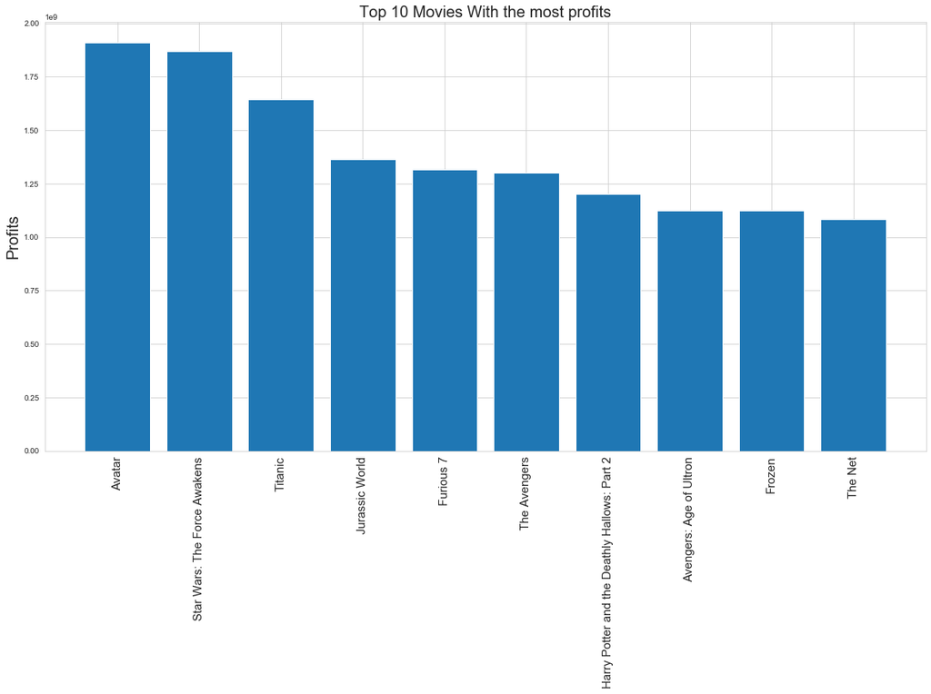

```python
# here, we will represnt the above result into bar chart
x=Top_Profits['ORIGINAL_TITLE']
y=Top_Profits['PROFITS']
ypos = np.arange(len(x))
plt.figure(figsize=(20, 10))
plt.xticks(ypos, x,rotation='vertical',fontsize=15)
plt.bar(ypos, y)
plt.title('Top 10 Movies With the most profits', fontsize=20)
plt.ylabel('Profits', fontsize=20)
```

as we can see here,The Avatr movies have th best profits, and The net movie have the lowest profits.

```python
# let's now check with the top 10 budget movies
Top_Budget = df.nlargest(10,'BUDGET')
Top_Budget
```

|  | ID | POPULARITY | BUDGET | REVENUE | ORIGINAL_TITLE | RUNTIME | RELEASE_DATE | VOTE_AVERAGE | RELEASE_YEAR | PROFITS |
| --- | --- | --- | --- | --- | --- | --- | --- | --- | --- | --- |
| 2244 | 46528 | 0 | 425000000 | 11087569 | The Warrior's Way | 100 | 2010-12-02 | 6.4 | 2010 | -413912431 |
| 3375 | 1865 | 4 | 380000000 | 1021683000 | Pirates of the Caribbean: On Stranger Tides | 136 | 2011-05-11 | 6.3 | 2011 | 641683000 |
| 7387 | 285 | 4 | 300000000 | 961000000 | Pirates of the Caribbean: At World's End | 169 | 2007-05-19 | 6.8 | 2007 | 661000000 |
| 14 | 99861 | 5 | 280000000 | 1405035767 | Avengers: Age of Ultron | 141 | 2015-04-22 | 7.4 | 2015 | 1125035767 |
| 6570 | 1452 | 1 | 270000000 | 391081192 | Superman Returns | 154 | 2006-06-28 | 5.3 | 2006 | 121081192 |
| 1929 | 38757 | 2 | 260000000 | 591794936 | Tangled | 100 | 2010-11-24 | 7.3 | 2010 | 331794936 |
| 4411 | 49529 | 1 | 260000000 | 284139100 | John Carter | 132 | 2012-03-07 | 6.0 | 2012 | 24139100 |
| 7394 | 559 | 2 | 258000000 | 890871626 | Spider-Man 3 | 139 | 2007-05-01 | 5.8 | 2007 | 632871626 |
| 5508 | 57201 | 1 | 255000000 | 89289910 | The Lone Ranger | 149 | 2013-07-03 | 6.0 | 2013 | -165710090 |
| 634 | 122917 | 10 | 250000000 | 955119788 | The Hobbit: The Battle of the Five Armies | 144 | 2014-12-10 | 7.1 | 2014 | 705119788 |

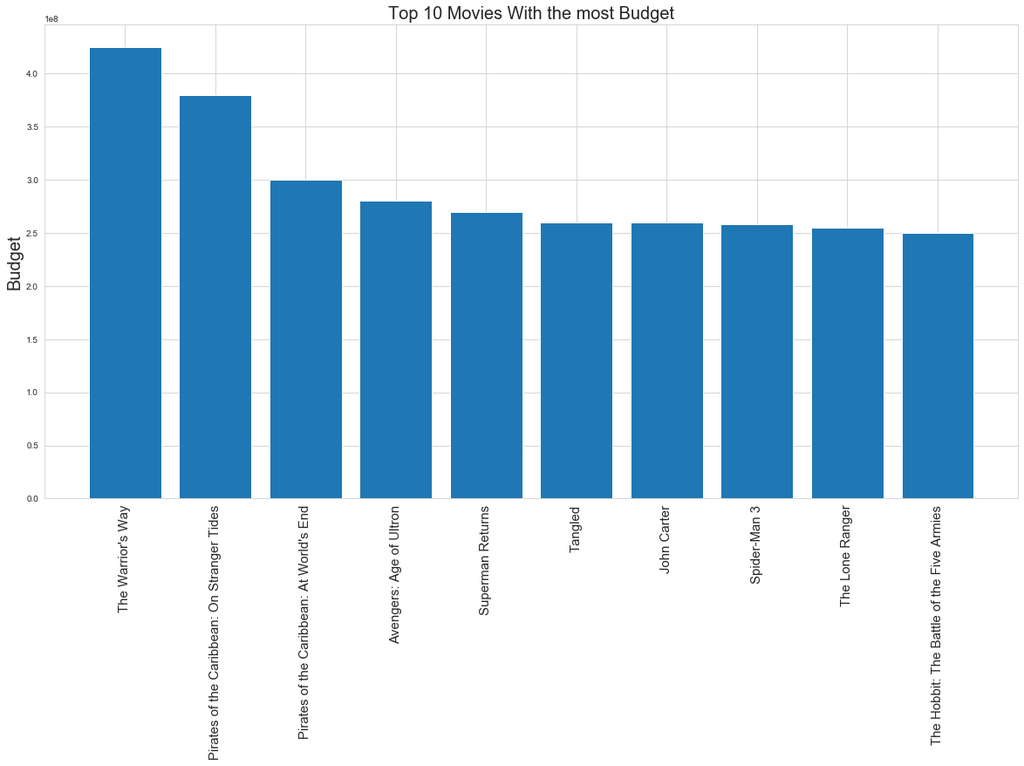

```python
x=Top_Budget['ORIGINAL_TITLE']
y=Top_Budget['BUDGET']
ypos = np.arange(len(x))
plt.figure(figsize=(20, 10))
plt.xticks(ypos, x,rotation='vertical',fontsize=15)
plt.bar(ypos, y)
plt.title('Top 10 Movies With the most Budget', fontsize=20)
plt.ylabel('Budget', fontsize=20)
```

here as we can see, The Warrior's Way movie more most budget and also at the same time it's not included with th best 10 profits movies!, really that's most profits for movies can come with less budgets.

## ### Research Question3: By what can vote average increasing?

```python
#to know the correlation between the columns with vote average, we need here to find the correlation between columns
corrMatrix = df.corr()
print(corrMatrix)
```

```
                    ID  POPULARITY    BUDGET   REVENUE   RUNTIME  \
ID            1.000000    0.185553 -0.027449 -0.001071 -0.035688
POPULARITY    0.185553    1.000000  0.433857  0.569454  0.207560
BUDGET       -0.027449    0.433857  1.000000  0.659968  0.260977
REVENUE      -0.001071    0.569454  0.659968  1.000000  0.233119
RUNTIME      -0.035688    0.207560  0.260977  0.233119  1.000000
VOTE_AVERAGE -0.001269    0.309790  0.024169  0.220537  0.351712
RELEASE_YEAR  0.489926    0.162363  0.268040  0.135341 -0.112453
PROFITS       0.004325    0.591082  0.530005  0.895815  0.220826

              VOTE_AVERAGE  RELEASE_YEAR   PROFITS
ID               -0.001269      0.489926  0.004325
POPULARITY        0.309790      0.162363  0.591082
BUDGET            0.024169      0.268040  0.530005
REVENUE           0.220537      0.135341  0.895815
RUNTIME           0.351712     -0.112453  0.220826
VOTE_AVERAGE      1.000000     -0.134246  0.262291
RELEASE_YEAR     -0.134246      1.000000  0.088619
PROFITS           0.262291      0.088619  1.000000
```

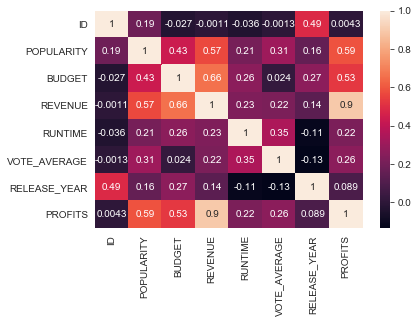

```python
# Try now to represent the above result into heatmap
sns.heatmap(corrMatrix, annot=True)
plt.show()
```

as we can see from the above, there is a relationship between Vote & runtime. lets try to check deeply

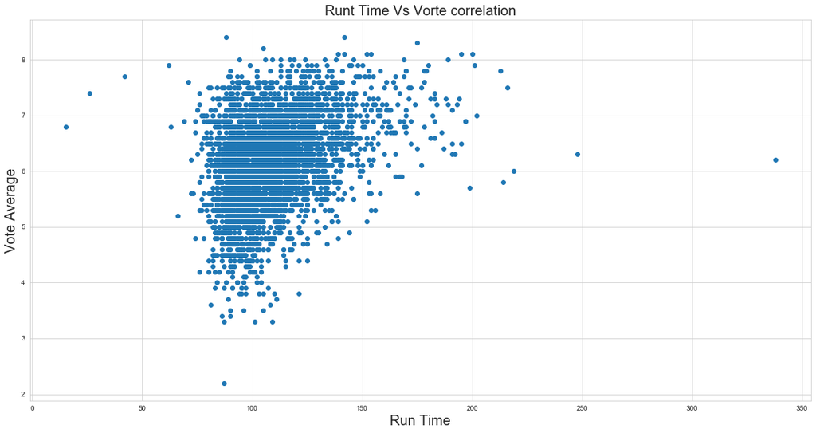

```python
# here we will plot scatterplot to see the correlation between Runtime and Vote Average
plt.figure(figsize=(20, 10))
plt.scatter(df['RUNTIME'], df['VOTE_AVERAGE'])
plt.title("Runt Time Vs Vorte correlation", fontsize = 20)
plt.xlabel("Run Time", fontsize = 20)
plt.ylabel("Vote Average", fontsize = 20)
plt.show()
```

#### ### Research Question4: Which month is better to relase the movie?

To answer this question, let's try to use profits as measure to now which month will achieve better profits

```python
# first of all we will convert relase date to mounth
df['RELEASE_DATE']=df['RELEASE_DATE'].dt.month
```

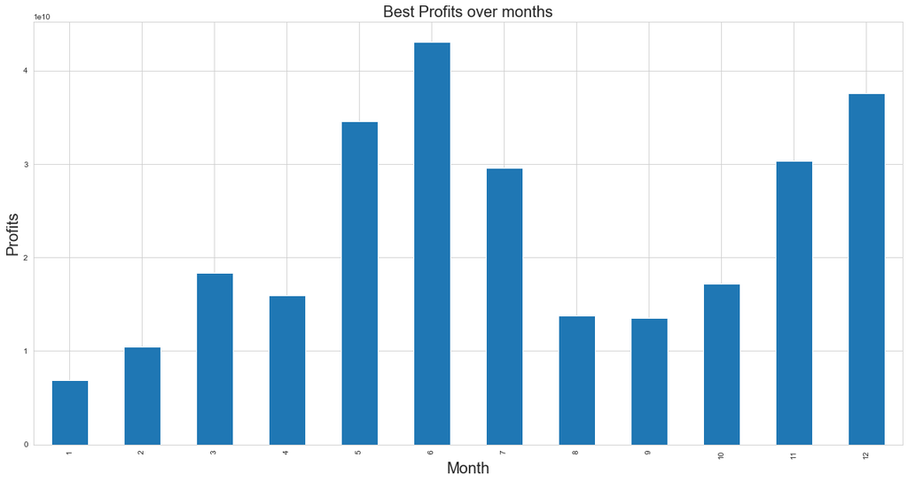

```python
# here we will group by release date with the sum of profits to know which month is better for release the movie
df.groupby('RELEASE_DATE')['PROFITS'].sum().plot(kind='bar',figsize=(20,10))
plt.title("Best Profits over months",fontsize = 20)
plt.xlabel('Month',fontsize = 20)
plt.ylabel('Profits',fontsize = 20)
sns.set_style("whitegrid")
```

from the result, june is better month to release the movie, and january is the bad month.

## Conclusions

> **Finally**:

## Sources

- panda,numpy,matplotlib documentations
- youtube.
- Slcak community.